```python
import pandas as pd
import numpy as np
import matplotlib.pyplot as plt
from IPython.display import Image
import math
```

```python
%matplotlib inline
```

# Reflections on teaching and why I'm here today

### No magic. Been doing similar things since joining OU in 1999 after ~10 years in industry.

Three intertwined facets:

- Building expertise
- In the classroom
- Beyond the classroom

Happy to discuss any of this over (virtual) coffee / tea :)

# Building expertise

- took a jillion classes in grad school (Industrial and Operations Engineering)
- worked at Beaumont Health, Henry Ford Health System and various consulting firms

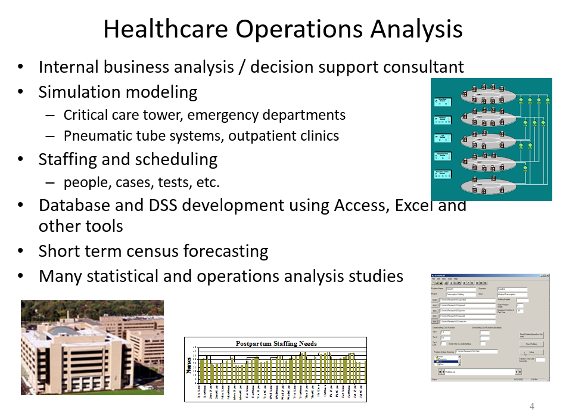

```python
Image(filename='images/professional_background.png')
```

# From industry to academia

- Bring practical mindset to the classroom
- Breathe life into abstract quant / techie topics
- Credibility with working professionals

# In the classroom - [Business Analysis and Modeling Studio](http://www.sba.oakland.edu/faculty/isken/courses/mis5460_f20/)

### Created in 2001

- Guided exploration and tutorials (**EX**: Date/time challenge on first night of class)
- Modeling analytics problem solving / coding behaviors via live spreadsheeting and coding
- talking through my thinking and doing debugging on the fly, self-deprecation

### Safety net - for me and for my students

- ability to troubleshoot lab/student techie issues on the fly
- screencasts that students can review at their own pace
- preparation

# In the classroom - [Practical Computing for Data Analytics](http://www.sba.oakland.edu/faculty/isken/courses/mis5470_f20/)

### Created in 2014

- Expand student vision beyond the Microsoft worldview
- Use open source technologies that are widely used in industry (Linux, R, Python)
- Jupyter notebooks and R Markdown documents facilitate the interactive studio environment (Quick Demo)
- Getting students to embrace the fact that when they make programming mistakes, it will almost always be their fault. :)
- Class is mixture of guided tutorials, problem solving challenges, games, open lab time

# In the classroom - BIO 111, 113, Ecology, [Stream Ecology](http://hselab.org/pages/processing-data-from-stream-temperature-loggers.html)

### Back in the classroom as a student

- Reminder of what it's like from the other side
- Led to [cross-disciplinary research collaboration with Scott Tiegs and some of his grad students](https://advances.sciencemag.org/content/5/1/eaav0486)
- Much overlap and similar pedagogical challenges between business analytics and environmental/ecological analytics --> [Software Carpentry](https://software-carpentry.org/lessons/)
- Have taken a bunch of short courses on teaching including the QOTCC course (great course!)

# Beyond the classroom

- Coordinator for Business Analytics Minor and leader in development of our graduate and undergraduate business analytics specialization, concentration, and certificate programs
- open access [curricular materials](http://www.sba.oakland.edu/faculty/isken/pages/teaching.html)
- analytics blogging at [hselab.org](http://hselab.org/)
- mentoring both current and former students (rec letters, career advice, grad school, professional)
- open source [software development](https://github.com/misken/hillmaker)
- pro-bono consulting - [Covid19 / CHIME example](https://github.com/misken)

# I like to learn

- in my domain area of analytics / industrial engineering / operations research and beyond
- the science of learning and new approaches to andragogy / pedagogy
- new technologies

# I like to solve real problems with

- modeling
- computing
- math/stat
- communication

I teach business analytics and it's really a combo of all of the above within a business context

# I like to share

- time and energy
- expertise and advice
- the things I create

# And ... I don't care much about

- who gets credit for what
- traditional metrics of success
- the status quo in higher ed